# Section Assignment 7

2/19/25

Things-to-Note: - 1) Don’t rename external files or edit them in any way 2) Don’t change the variable names 3) Don’t destroy or overwrite any variables 4) Don’t use global path in your script. Instead use “setwd()” interactively in the console, but don’t include this code in your submission

If you don’t take above instructions into account it might effect your grades. *** Your Information: -

```r
firstname <- "Zakir"   # example: "Liam"
lastname <- "Alibhai"  # example: "Mueller"
username <- "zalibhai"  #example: "lomueller"   Do not include the "@ucsd.edu" part!
```

Since we have already downloaded and installed the necessary packages, this week, simply load the tidyverse functions into your working library:

This week you will practice answering a research question step by step. Think of it as practice for your term project!

This week, your assignment works with simulated data from the common side-blotched lizard (Uta stansburiana).

https://en.wikipedia.org/wiki/Common_side-blotched_lizard

Step 1. Before we even collect our data (In this case, before we upload the simulated data), we need to come up with our analysis plan! This should include the statistical hypothesis we are testing, the structure of the data, the type of model and statistical test we will use to test the model, and any assumptions the data need to meet to run the test appropriately.

Null Hypothesis:

```r
q1 <- "There is no difference in plasma testosterone between the three male color morphs of U. stansburiana."
```

Alternate Hypothesis:

```r
q2 <- "There is a difference in plasma testosterone between the three male color morphs of U. stansburiana."
```

Question 3, 4: What is the structure of the data? Identify what the independent and dependent variable are in this example and what type of data each is (“continuous”, “count”, “ordinal”, “binomial”, “categorical”). Your answer should be one of the 5 words above, in quotes, and that is it. For example: q1 <- “binomial”

Independent variable:

```r
q3 <- "categorical"
```

Dependent variable:

```r
q4 <- "continuous"
```

Step 2. Import your data, and make it tidy.

Question 5: Import the data you downloaded from canvas this week.

```r
LizardData<-read.csv(file = "Week7Lizards.csv")
head(LizardData)
```

```
##     Orange     Blue   Yellow
## 1 131.8381 116.2003 148.1857
## 2 140.0961 104.3322 125.1150
## 3 139.2333 100.9225 110.1261
## 4 120.2647 118.0198 101.1295
## 5 158.9764 154.1019 105.5951
## 6 122.3164 132.2953 146.4377
```

```r
### This chunk of code is for grading purposes.
### Don't change/delete this chunk of code.
q5 <- LizardData
```

Question 6: Make the data table a tidy table. Hint: you have 3 columns of data which need to be included in pivot_longer()!

```r
TidyLizard <- pivot_longer(LizardData, cols = 1:3, names_to = "color", values_to = "plasmaTestosterone")
head(TidyLizard)
```

```
## # A tibble: 6 × 2
##   color  plasmaTestosterone
##   <chr>               <dbl>
## 1 Orange               132.
## 2 Blue                 116.
## 3 Yellow               148.
## 4 Orange               140.
## 5 Blue                 104.
## 6 Yellow               125.
```

```r
### This chunk of code is for grading purposes.
### Don't change/delete this chunk of code.
q6 <- TidyLizard
```

Step 3. Build the appropriate statistical model and test your model assumptions (normal residuals).

Question 7: Generate an appropriate statistical model for the relationship between plasma testosterone and color morph.

```r
Model1<-lm(plasmaTestosterone ~ color, data = TidyLizard)

Model1
```

```
##
## Call:
## lm(formula = plasmaTestosterone ~ color, data = TidyLizard)
##
## Coefficients:
## (Intercept)  colorOrange  colorYellow
##     121.201       17.402       -4.286
```

```r
### This chunk of code is for grading purposes.
### Don't change/delete this chunk of code.
q7 <- Model1
```

Question 8: Use visualizations and tests to determine if the data are normally distributed.

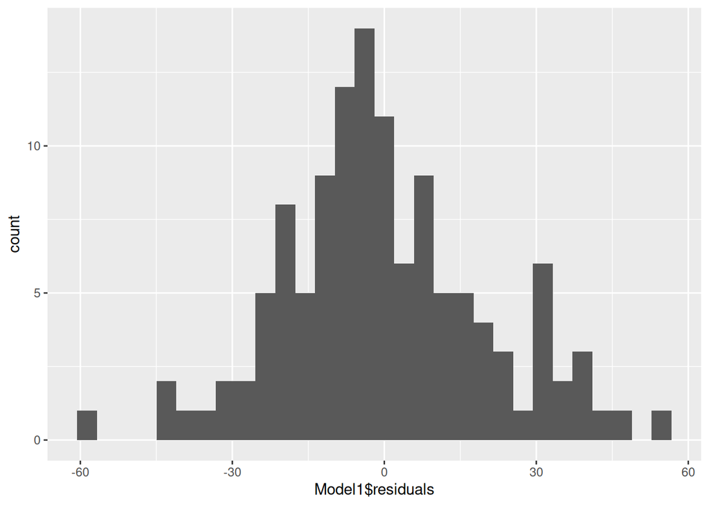

```r
#hist(Model1$residuals)
Histogram1<-ggplot(data = Model1, mapping = aes(x = Model1$residuals)) +
  geom_histogram()
Histogram1
```

```r
#Test for normality using ks test.
ks.test(Model1$residuals,"pnorm",mean(Model1$residuals),sd(Model1$residuals))
```

```
##
##  Asymptotic one-sample Kolmogorov-Smirnov test
##
## data:  Model1$residuals
## D = 0.078596, p-value = 0.4488
## alternative hypothesis: two-sided
```

```r
### This chunk of code is for grading purposes.
### Don't change/delete this chunk of code.
q8 <- Histogram1
```

Question 9: Are the testosterone data residuals normally distributed? (Use a TRUE or FALSE statement only)

```r
q9 <- TRUE
```

Step 4. Test your null hypothesis.

Question 10: Use an ANOVA to test the null hypothesis. Consult the PDF help file for code associated with performing an Analysis of Variance in R.

```r
q10 <-anova(Model1)

q10
```

```
## Analysis of Variance Table
##
## Response: plasmaTestosterone
##            Df Sum Sq Mean Sq F value   Pr(>F)
## color       2  10554  5277.2   12.95 8.31e-06 ***
## Residuals 117  47680   407.5
## ---
## Signif. codes:  0 '***' 0.001 '**' 0.01 '*' 0.05 '.' 0.1 ' ' 1
```

Step 5. Post-hoc interpretation of the model and graphical representation.

Question 11: Perform a Tukey’s Honest Standard Deviation post-hoc test. Hint, Tukey needs an aov object to run.

```r
turkey<-TukeyHSD(x = aov(Model1))
q11 <-TukeyHSD(aov(TidyLizard$plasmaTestosterone ~ TidyLizard$color))
#turkey
q11
```

```
##   Tukey multiple comparisons of means
##     95% family-wise confidence level
##
## Fit: aov(formula = TidyLizard$plasmaTestosterone ~ TidyLizard$color)
##
## $`TidyLizard$color`
##                     diff        lwr        upr     p adj
## Orange-Blue    17.402069   6.686295  28.117844 0.0005524
## Yellow-Blue    -4.286241 -15.002015   6.429534 0.6101407
## Yellow-Orange -21.688310 -32.404085 -10.972535 0.0000138
```

Question 12: Build a graph that demonstrates the differences in testosterone between the 3 color morphs. Use the example figure (also found on canvas) as a guide. Hint: The colors I used were “cornflowerblue”,“darkorange2”, and “gold1”. Hint 2: To get the letters to display above each bar, I used the `annotate()` function. Hint 3: I had to reset my lower and upper Y limits to 60 and 200.

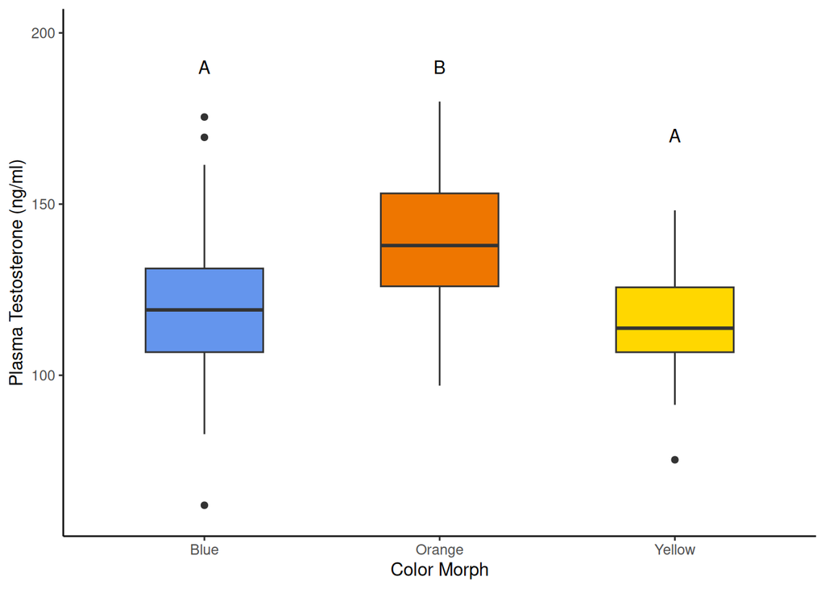

```r
plot1<-ggplot(data=TidyLizard,mapping=aes(x=color,y=plasmaTestosterone,fill=color)) +
  theme_classic() +
  coord_cartesian(ylim=c(60,200)) +
  scale_fill_manual(values = c("cornflowerblue", "darkorange2", "gold1"))+
  xlab("Color Morph") +
  ylab("Plasma Testosterone (ng/ml)") +
  annotate(geom="text",x=c("Blue","Orange","Yellow"),y=c(190,190,170),label=c("A","B","A"))+
  guides(fill="none")+
  geom_boxplot(width = 0.5)
plot1
```

```r
### This chunk of code is for grading purposes.
### Don't change/delete this chunk of code.
q12 <- plot1
```

Once you are done, make sure there are no errors. Save the .rmd file with your name and the week number in the file name:

(for example: “DONE_Liam_Mueller_Section_Assignment_7.rmd”).

Then upload this pdf file to canvas under the Week 7 module before the deadline.